# EECIST23 • EXP2 - Statistiques bivariées

Auteur·rice

Yayé MOUSSA & Malika MADELIN

# L’évolution spatiotemporelle des précipitations dans l’extrême sud-ouest nigérien, Liptako Nigérien

L’**objectif de l’exercice** proposé est d’analyser l’**évolution temporelle des précipitations** dans la région de Tillabéri, à l’extrême **sud-ouest du Niger** à la frontière du Mali et du Burkina Faso. Les données climatiques utilisées, des séries de moyennes annuelles de 1981 à 2021 (41 ans), proviennent de la Direction départementale de l’agriculture de Téra (Niger). Elles sont issues de la compilation des plusieurs stations météorologiques notamment des communes de Téra, Gorouol, Bankilaré et Gothèye. Ces communes appartiennent à la région du Liptako Gourma, caractérisée par un climat de type sud sahélien, avec une pluviométrie moyenne annuelle de 500 mm, lors d’une saison des pluies intense, et une évapotranspiration potentielle de plus 2000 mm par an.

**Code R pour afficher la carte ci-dessous**

```r
# lancement de la librairie leaflet (webmap)
library(leaflet)

# tableau de données avec les coordonnées des stations météo
stations <- data.frame(station = c("Bankilare","Tera", "Gorouol", "Gotheye"),
                       latitude = c(14.5441, 14.0058, 14.7994, 13.9652),
                       longitude = c(0.5435, 0.7515, 0.3761, 1.465)
                       )

# carte de localisation des stations
leaflet(stations) %>% addTiles() %>%
  # ajout des points (en fonction de la lat/long, paramètres d'affichage...)
  addCircleMarkers(lng = ~longitude, lat = ~latitude,
                   label= ~station, labelOptions = labelOptions(noHide = T),
                   radius = 7, stroke=FALSE,
                   fillColor = "#c4327e", fillOpacity = 1) %>%
  # ajout du carton de situation
  addMiniMap(position = "topright", toggleDisplay = TRUE,
             tiles = providers$OpenTopoMap) %>%
  # ajout de l'échelle
  addScaleBar(position = "bottomleft", options=scaleBarOptions(imperial=FALSE))
```

[interactive chart not shown]

D’un point de vue statistique, il s’agit d’**étudier la relation d’une variable (ici, les précipitations) avec le temps (années)**. Observe-t-on une **tendance significative** à la hausse ou à la baisse de ce paramètre climatique depuis 40 ans ? Cette tendance est-elle similaire selon les stations étudiées ? Cette analyse de relations permet plus largement de confronter ces données aux changements climatiques et environnementaux à l’échelle du Sahel nigérien, d’évaluer les incidences sur les ressources en eau de surface, encore au centre des systèmes d’approvisionnement en eau des communautés rurales agropastorales. L’analyse de ces éléments permet de dégager les nouvelles tendances climatiques (modèles climatiques) qui se mettent ou qui peuvent se mettre en place et les risques que cela peut représenter. Se posent alors les questions de recompositions socio-spatiales, les tensions et conflits potentiels sur la ressource en eau, les nouvelles solidarités communautaires et multi-acteurs autour de l’exploitation de l’eau.

**Quelles sont les différentes **étapes méthodologiques** pour vérifier la relation entre précipitations et temps ?**

Graphique (nuage de points) ⭢ Hypothèses ⭢ Calcul du r ⭢ Significativité ⭢ Modélisation

Voici le [lien](https://mmadelin.github.io/EECIST23_EXP2/EXP2_statsbivar.html) pour revoir le cours.

## 1. Les données utilisées

Les données climatiques utilisées proviennent de la **Direction départementale de l’agriculture de Téra** (Niger) et ont été rassemblées par Yayé MOUSSA. Nous avons retenu ici **quatre stations météorologiques** installées sur les communes de **Téra, Gorouol, Bankilaré et Gothèye**. Pour chaque station, nous disposons des données mensuelles de **précipitations** (totaux en mm) et de **températures** (moyennes des minimales et des maximales, en °C).

| station | annee | mois | pluie | Tmin | Tmax |
| --- | --- | --- | --- | --- | --- |
| Bankilare | 1981 | 1 | 0.00 | 10.94 | 33.40 |
| Bankilare | 1981 | 2 | 0.00 | 14.41 | 37.76 |
| Bankilare | 1981 | 3 | 0.00 | 18.55 | 41.42 |
| Bankilare | 1981 | 4 | 0.00 | 19.91 | 43.57 |
| Bankilare | 1981 | 5 | 42.19 | 25.48 | 43.39 |
| Bankilare | 1981 | 6 | 21.09 | 23.89 | 42.53 |
| Bankilare | 1981 | 7 | 94.92 | 22.44 | 37.99 |

Source : Direction départementale de l’agriculture de Téra (Niger) ; données rassemblées par Yayé MOUSSA

## 2. Téléchargement et ouverture du projet

Après avoir téléchargé et dézippé le [**fichier de l’exercice**](https://ee2023.netlify.app/modules/support/EXP2_Exos.zip), ouvrez le projet (*EXP2_Exo_ClimNiger.Rproj*) en allant dans le menu *File > OpenFile* de RStudio ou bien en double-cliquant sur ce fichier depuis votre répertoire de documents. Ce **projet** réunit tous les fichiers et documents relatifs à un même projet (programmes, mais aussi jeux de données, etc.) au sein d’un **dossier unique**.

Nb : Pour fermer le projet, sur l’icône “Projet” en haut à droite, “Close Project”

Vous pouvez voir dans le répertoire */data/* le fichier .CSV des données climatiques, qu’on va importer en exécutant la commande ci-dessous :

```r
clim_niger <- read.csv("data/Niger_DataClim_19812021.csv",
                       sep = ",", dec = ".")
```

Nb : nous précisons ici la virgule comme séparateur et le point pour les décimales

À partir de ces données, initialement à l’échelon mensuel, nous calculons les totaux annuels des précipitations et les moyennes annuelles des températures, à partir de la libraire *dplyr* (pour plus d’aide dessus : [le site web dédié à dplyr](https://dplyr.tidyverse.org/), [la *cheatsheet* de dplyr en pdf](https://github.com/rstudio/cheatsheets/raw/master/data-transformation.pdf) ou encore [le blog de Lise Vaudor](https://perso.ens-lyon.fr/lise.vaudor/dplyr/)).

```r
# Lancement de la librairie (après son installation si cela est nécessaire)
library(dplyr)

# création d'un nouveau dataframe = clim_niger_annuel
clim_niger_annuel <- clim_niger  %>%
  # regroupant par station et par année
  group_by(station, annee) %>%
  # les résumés statistiques (ici somme, moyenne et nombre)
  summarise(
    sum_pluie = sum(pluie),
    moy_tmin = mean(Tmin, na.rm=TRUE),
    moy_tmax = mean(Tmax, na.rm=TRUE),
    nb_annee = n())
```

Voici les premières lignes du tableau résultant (que vous pouvez visualiser avec *View(clim_niger_annuel)* ou en cliquant sur le *dataframe* dans la fenêtre *Environment*) :

| station | annee | sum_pluie | moy_tmin | moy_tmax | nb_annee |
| --- | --- | --- | --- | --- | --- |
| Bankilare | 1981 | 279.49 | 18.99083 | 38.93250 | 12 |
| Bankilare | 1982 | 279.48 | 18.44833 | 38.69833 | 12 |
| Bankilare | 1983 | 326.95 | 18.33750 | 39.60167 | 12 |
| Bankilare | 1984 | 221.48 | 18.73500 | 39.47417 | 12 |
| Bankilare | 1985 | 274.22 | 18.04083 | 38.64917 | 12 |
| Bankilare | 1986 | 311.13 | 18.84583 | 39.42333 | 12 |
| Bankilare | 1987 | 242.57 | 19.00250 | 40.58750 | 12 |
| Bankilare | 1988 | 348.04 | 18.50250 | 39.53833 | 12 |
| Bankilare | 1989 | 379.69 | 18.36500 | 38.86167 | 12 |
| Bankilare | 1990 | 284.75 | 19.63917 | 40.20333 | 12 |

## 3. Analyse des relations précipitations - temps

Existe-t-il des **relations significatives** entre précipitations et temps ?  
Autrement dit, observe-t-on une **tendance significative à la hausse ou à la baisse** des totaux annuels de précipitations ?  
Est-ce que cette tendance est identique pour les quatre stations ?

Pour commencer, on va sélectionner une station, par ex Téra :

```r
Tera <- clim_niger_annuel %>% filter(station == "Tera")

# avec R-base : Tera <- clim_niger_annuel[clim_niger_annuel$station == "Tera",]
```

#### • Graphique cartésien (nuage de points) pour avoir une idée de la forme, de l’intensité et du sens de la relation

La structure du code en `R-base` pour représenter le nuage de points est `plot(tableau$variableX, tableau$variableY)`, en précisant la variable Y à expliquer et la variable X explicative. Ici, on cherche à expliquer les totaux de précipitations en fonction du temps (années).

**Vous essayez ? si besoin, la correction se trouve ci-dessous.**

**Solution avec R-base**

```r
plot(Tera$annee, Tera$sum_pluie)
```

**Solution avec la librairie ggplot2**

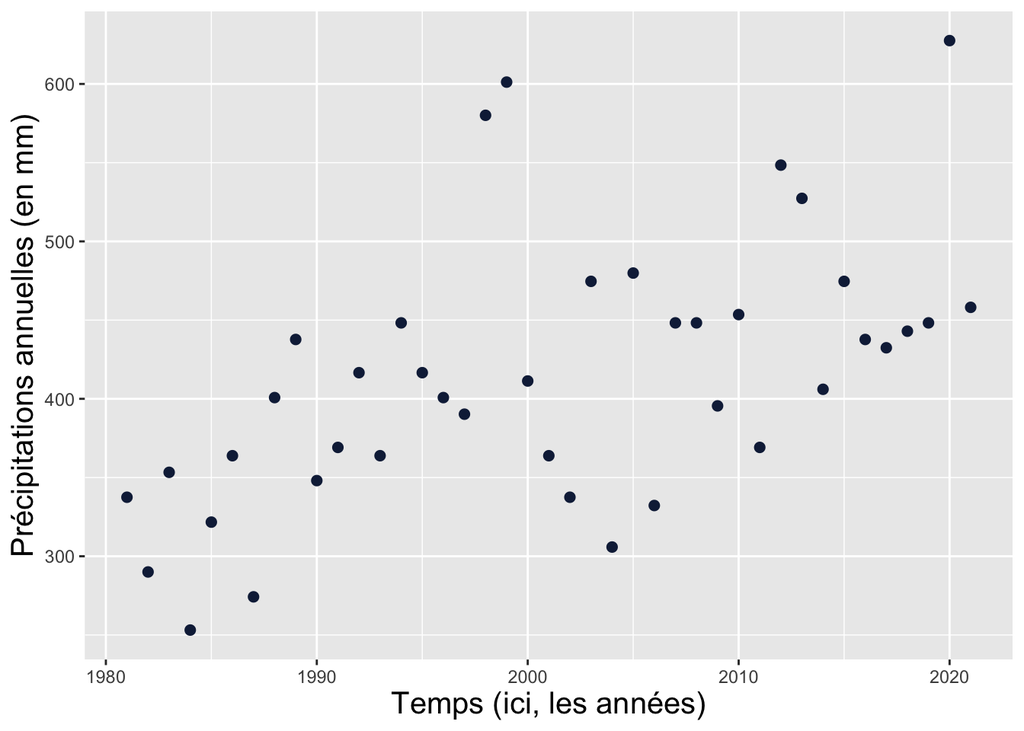

```r
library(ggplot2)
ggplot(Tera) +
  theme(axis.title = element_text(size = 15)) +
  aes(x = annee, y = sum_pluie) +
  geom_point(shape = "circle", size = 2, colour = "#112446") +
  labs(x = "Temps (ici, les années)", y = "Précipitations annuelles (en mm)")
```

**Quelle est votre lecture de ce graphique ?**

Plus on se rapproche des années récentes, plus les totaux annuels de précipitations à Téra ont tendance à être plus élevés. Les pluies semblent augmenter avec le temps, depuis les années 1980 pour cette station. Pour autant, on peut observer une variabilité interannuelle des précipitations, avec des années connaissant des totaux importants (par ex, 1998 ou 1999) ou à l’inverse plutôt faibles (2004).

#### • Calcul du coefficient de corrélation et vérification de la significativité

Il s’agit maintenant de tester la significativité de cette relation, c’est-à-dire de confirmer ou d’infirmer l’hypothèse nulle H0 d’indépendance entre précipitations et temps, à partir du calcul du **coefficient de Bravais-Pearson** et de la significativité associée *p-value*.

Le plus simple est d’utiliser la fonction `cor.test(tableau$variableX, tableau$variableY)`, en précisant la variable Y à expliquer et la variable X explicative.

**Vous essayez ?**

**Solution avec R-base**

```r
cor.test(Tera$annee, Tera$sum_pluie)
```

Voici les résultats :

```
    Pearson's product-moment correlation

data:  Tera$annee and Tera$sum_pluie
t = 4.1991, df = 39, p-value = 0.0001503
alternative hypothesis: true correlation is not equal to 0
95 percent confidence interval:
 0.3022188 0.7388109
sample estimates:
      cor
0.5579887
```

**Quelle est votre lecture de ces résultats ?**

Le coefficient de Bravais Pearson (cor : ~0.558) est ici positif, témoignant d’une possible relation positive : plus le temps avance, plus les précipitations augmentent. La *p-value*, bien inférieure à 1%, avec un degré de liberté *df* de 39, confirme la relation.

**Les précipitations à la station de Téra ont significativement augmenté depuis 1981.**

Retrouve-t-on la **même tendance à la hausse des précipitations pour les autres stations** ? Pour quelle station, les précipitations ont-elles le plus augmenté depuis les années 1980 ?

Nb : vous pouvez reprendre les étapes précédentes de Téra pour les autres : sélection des données, graphique cartésien, corrélation et significativité.

**À VOUS DE JOUER ! Vous trouverez la réponse ci-dessous.**

Les 4 stations du sud-ouest du Niger connaissent une augmentation significative des précipitations (avec un risque d’erreur < 2%), depuis les années 1980. Cette hausse est plus significative pour les stations de Gorouol (r = 0.72) et Bankilare (0.68), que pour celle de Gotheye (0.37).

## 4. Modélisation de la relation et analyse des résidus

En repartant de l’exemple des précipitations à Téra, on souhaite à présent **modéliser la relation**, en d’autres termes exprimer l’**équation du modèle linéaire** « Précipitations en fonction du temps » : *Précipitations = a.temps + b*, avec *a* la pente et *b* l’ordonnée à l’origine.

Cette **régression linéaire** permettra de **résumer** la relation, d’**estimer** des valeurs manquantes, voire les précipitations dans le futur (même s’il faut être très prudent·e, cela suppose une stationnarité de la relation).

#### • Quelle est l’**équation du modèle** *Précipitations = a.temps + b* ?

La structure du code en `R-base` pour trouver le modèle linéaire est `lm(tableau$variableY ~ tableau$variableX)`, en précisant la variable Y à expliquer et la variable X explicative. La fonction `lm()` correspond à *linear model* et le *tilde* ~ exprime « en fonction de ».

**Vous essayez ?**

**Solution avec R-base**

```r
lm_result <- lm(Tera$sum_pluie ~ Tera$annee)

# ici on enregistre les résultats dans un objet liste *lm_result* comprenant les coefficients de la régression linéaire, les valeurs estimées, les résidus, etc.

# pour avoir le détail des résultats :
summary(lm_result)
```

Voici les résultats :

```
Call:
lm(formula = Tera$sum_pluie ~ Tera$annee)

Residuals:
     Min       1Q   Median       3Q      Max
-120.271  -44.513    0.833   37.197  194.592

Coefficients:
              Estimate Std. Error t value Pr(>|t|)
(Intercept) -7406.7432  1862.5960  -3.977 0.000294 ***
Tera$annee      3.9086     0.9308   4.199 0.000150 ***
---
Signif. codes:  0 '***' 0.001 '**' 0.01 '*' 0.05 '.' 0.1 ' ' 1

Residual standard error: 70.52 on 39 degrees of freedom
Multiple R-squared:  0.3114,    Adjusted R-squared:  0.2937
F-statistic: 17.63 on 1 and 39 DF,  p-value: 0.0001503
```

**Quelle est votre lecture de ces résultats ?**

La relation Précipitations-Temps est significative, avec un risque d’erreur inférieur à 1% (*p-value*). Les deux coefficients affichés sont l’ordonnée à l’origine (*b* ; ici [(Intercept)]) et la pente (*a*) de l’équation $y = a.x + b$. D’après le modèle construit, les précipitations à Téra augmenteraient d’environ 3.9 mm chaque année depuis les années 1980. Elles seraient d’environ -7410 mm en l’an 0 : cela est impossible, on est d’accord !, les précipitations ne peuvent être négatives ; cela montre les limites de validité du modèle qui repose ici sur une quarantaine d’années.

Le modèle Préci~Temps a un coefficient $r$ de 0.56, donc un coefficient de détermination $r^2$ de 0.31 : 31% de la variation des précipitations s’explique par une évolution temporelle, et donc 69% par d’autres facteurs.

Les coefficients *a* et *b* du modèle linéaire permettent alors de représenter, sur un même graphique, le nuage de points et la droite de régression (ici en ▬).

**Code R pour afficher le graphique ci-dessous**

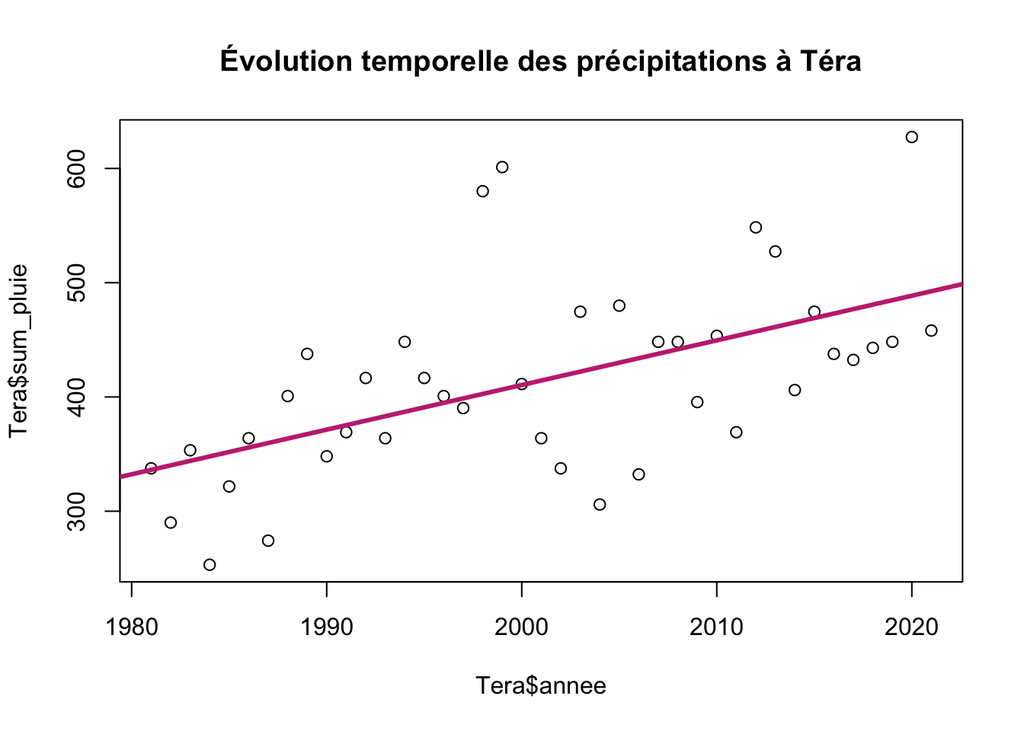

```r
plot(Tera$annee, Tera$sum_pluie,
     main = "Évolution temporelle des précipitations à Téra")
abline(lm(Tera$sum_pluie ~ Tera$annee), col = "#c4327e", lwd=3)
```